# CustomerLens-Analytics.

Anatomía del cliente de alto valor

Francisco Javier Ruiz Rodríguez

## 1. Introducción

En cualquier estrategia comercial, identificar y comprender a los **clientes más valiosos** es una prioridad. No todos los clientes generan el mismo retorno: mientras algunos concentran volúmenes de gasto elevados y sostienen las líneas de negocio más rentables, otros presentan niveles de compra marginales. Conocer qué factores demográficos, de comportamiento y de interacción distinguen a unos de otros resulta clave para diseñar acciones de fidelización, campañas de marketing y políticas comerciales.

En este contexto, formulamos la siguiente pregunta de investigación:

> ¿Qué factores demográficos y de comportamiento caracterizan a los clientes de alto valor (alto gasto) frente a los de bajo valor?

Responder a esta cuestión es especialmente relevante porque:

- **Permite focalizar recursos**: invertir en retener clientes de alto valor es más eficiente que captación masiva indiscriminada.
- **Facilita la segmentación**: conocer el perfil de cada segmento permitiría diseñar acciones diferenciadas.
- **Complementa otros análisis del proyecto**: mientras que otros compañeros estudian la rentabilidad de los descuentos (Andrés), el canal de compra (Jaime, Pablo) o la relación entre familia y consumo (grupo), este estudio aporta una perspectiva integral de **valor del cliente**.

Para ello segmentaremos los clientes en tres grupos según su gasto total (`Total_Spending`) y compararemos sus perfiles en un amplio conjunto de variables.

### 1.1. Objetivos

Este análisis persigue los siguientes objetivos:

- Segmentar la base de clientes en tres niveles de valor (bajo, medio, alto) según su gasto total.
- Describir y comparar el perfil demográfico y de comportamiento de cada segmento.
- Evaluar formalmente si las diferencias entre segmentos son estadísticamente significativas.
- Identificar las variables con mayor poder de diferenciación entre clientes de alto y bajo valor.
- Sintetizar un perfil tipo del cliente de alto valor para orientar decisiones estratégicas.

## 2. Carga de datos y variables de trabajo

Cargamos las librerías necesarias e importamos el dataset preprocesado, restaurando los tipos de las variables categóricas para mantener coherencia con el resto del proyecto.

```r
library(dplyr)
library(readr)
library(ggplot2)
library(tidyr)

data <- read_csv("./data/marketing_campaign_processed.csv", show_col_types = FALSE)

# Restauramos los tipos de las variables categóricas
data$Education <- factor(
  data$Education,
  levels = c("Basic", "2n Cycle", "Graduation", "Master", "PhD"),
  ordered = TRUE
)
data$Marital_Status <- factor(
  data$Marital_Status,
  levels = c("Single", "Together", "Married", "Divorced", "Widow")
)
```

### 2.1. Verificación de calidad de datos

Antes de empezar el análisis verificamos que las variables clave no presentan valores faltantes ni valores imposibles. Siguiendo las buenas prácticas del proyecto, el preprocesamiento ya cubrió los problemas más graves; este check rápido garantiza consistencia local.

```r
# NAs en variables clave
data %>%
  summarise(
    NA_Spending  = sum(is.na(Total_Spending)),
    NA_Income    = sum(is.na(Income)),
    NA_Age       = sum(is.na(Age)),
    NA_Recency   = sum(is.na(Recency)),
    NA_Purchases = sum(is.na(Total_Purchases))
  )
```

```
## # A tibble: 1 × 5
##   NA_Spending NA_Income NA_Age NA_Recency NA_Purchases
##         <int>     <int>  <int>      <int>        <int>
## 1           0         0      0          0            0
```

```r
# Valores extremos o imposibles
cat("Clientes con gasto < 0:", sum(data$Total_Spending < 0, na.rm = TRUE), "\n")
```

```
## Clientes con gasto < 0: 0
```

```r
cat("Clientes con Income < 0:", sum(data$Income < 0, na.rm = TRUE), "\n")
```

```
## Clientes con Income < 0: 0
```

```r
cat("Clientes con Age > 100:", sum(data$Age > 100, na.rm = TRUE), "\n")
```

```
## Clientes con Age > 100: 0
```

```r
cat("Clientes con Deals_Ratio > 1:", sum(data$Deals_Ratio > 1, na.rm = TRUE), "\n")
```

```
## Clientes con Deals_Ratio > 1: 0
```

> **Resultado:** Todas las variables clave están completas y dentro de rangos válidos. El análisis opera sobre datos limpios.

Las variables que utilizaremos abarcan todas las dimensiones del dataset:

- **Variable de segmentación**: `Total_Spending` (gasto total en los últimos 2 años).
- **Variables demográficas**: `Age`, `Income`, `Education`, `Marital_Status`, `Children_Home`, `Has_Children`.
- **Variables de gasto por categoría**: `MntWines`, `MntFruits`, `MntMeatProducts`, `MntFishProducts`, `MntSweetProducts`, `MntGoldProds`.
- **Variables de comportamiento de compra**: `Total_Purchases`, `NumWebPurchases`, `NumCatalogPurchases`, `NumStorePurchases`, `NumDealsPurchases`, `Deals_Ratio`, `NumWebVisitsMonth`.
- **Variables de campañas**: `Total_Campaigns_Accepted`, `Responded_Any_Campaign`.
- **Variables temporales**: `Recency`, `Tenure_Days`.

```r
str(data)
```

```
## spc_tbl_ [2,202 × 36] (S3: spec_tbl_df/tbl_df/tbl/data.frame)
##  $ ID                      : num [1:2202] 5524 2174 4141 6182 5324 ...
##  $ Year_Birth              : num [1:2202] 1957 1954 1965 1984 1981 ...
##  $ Education               : Ord.factor w/ 5 levels "Basic"<"2n Cycle"<..: 3 3 3 3 5 4 3 5 5 5 ...
##  $ Marital_Status          : Factor w/ 5 levels "Single","Together",..: 1 1 2 2 3 2 4 3 2 2 ...
##  $ Income                  : num [1:2202] 58138 46344 71613 26646 58293 ...
##  $ Kidhome                 : num [1:2202] 0 1 0 1 1 0 0 1 1 1 ...
##  $ Teenhome                : num [1:2202] 0 1 0 0 0 1 1 0 0 1 ...
##  $ Dt_Customer             : Date[1:2202], format: "2012-09-04" "2014-03-08" ...
##  $ Recency                 : num [1:2202] 58 38 26 26 94 16 34 32 19 68 ...
##  $ MntWines                : num [1:2202] 635 11 426 11 173 520 235 76 14 28 ...
##  $ MntFruits               : num [1:2202] 88 1 49 4 43 42 65 10 0 0 ...
##  $ MntMeatProducts         : num [1:2202] 546 6 127 20 118 98 164 56 24 6 ...
##  $ MntFishProducts         : num [1:2202] 172 2 111 10 46 0 50 3 3 1 ...
##  $ MntSweetProducts        : num [1:2202] 88 1 21 3 27 42 49 1 3 1 ...
##  $ MntGoldProds            : num [1:2202] 88 6 42 5 15 14 27 23 2 13 ...
##  $ NumDealsPurchases       : num [1:2202] 3 2 1 2 5 2 4 2 1 1 ...
##  $ NumWebPurchases         : num [1:2202] 8 1 8 2 5 6 7 4 3 1 ...
##  $ NumCatalogPurchases     : num [1:2202] 10 1 2 0 3 4 3 0 0 0 ...
##  $ NumStorePurchases       : num [1:2202] 4 2 10 4 6 10 7 4 2 0 ...
##  $ NumWebVisitsMonth       : num [1:2202] 7 5 4 6 5 6 6 8 9 20 ...
##  $ AcceptedCmp3            : num [1:2202] 0 0 0 0 0 0 0 0 0 1 ...
##  $ AcceptedCmp4            : num [1:2202] 0 0 0 0 0 0 0 0 0 0 ...
##  $ AcceptedCmp5            : num [1:2202] 0 0 0 0 0 0 0 0 0 0 ...
##  $ AcceptedCmp1            : num [1:2202] 0 0 0 0 0 0 0 0 0 0 ...
##  $ AcceptedCmp2            : num [1:2202] 0 0 0 0 0 0 0 0 0 0 ...
##  $ Complain                : num [1:2202] 0 0 0 0 0 0 0 0 0 0 ...
##  $ Response                : num [1:2202] 1 0 0 0 0 0 0 0 1 0 ...
##  $ Age                     : num [1:2202] 57 60 49 30 33 47 43 29 40 64 ...
##  $ Children_Home           : num [1:2202] 0 2 0 1 1 1 1 1 1 2 ...
##  $ Has_Children            : num [1:2202] 0 1 0 1 1 1 1 1 1 1 ...
##  $ Total_Spending          : num [1:2202] 1617 27 776 53 422 ...
##  $ Total_Purchases         : num [1:2202] 22 4 20 6 14 20 17 8 5 1 ...
##  $ Deals_Ratio             : num [1:2202] 0.136 0.5 0.05 0.333 0.357 ...
##  $ Total_Campaigns_Accepted: num [1:2202] 0 0 0 0 0 0 0 0 0 1 ...
##  $ Responded_Any_Campaign  : num [1:2202] 1 0 0 0 0 0 0 0 1 1 ...
##  $ Tenure_Days             : num [1:2202] 848 298 497 324 346 478 778 602 573 293 ...
##  - attr(*, "spec")=
##   .. cols(
##   ..   ID = col_double(),
```

[output cut: 22 more lines]

```
##   ..   AcceptedCmp1 = col_double(),
##   ..   AcceptedCmp2 = col_double(),
##   ..   Complain = col_double(),
##   ..   Response = col_double(),
##   ..   Age = col_double(),
##   ..   Children_Home = col_double(),
##   ..   Has_Children = col_double(),
##   ..   Total_Spending = col_double(),
##   ..   Total_Purchases = col_double(),
##   ..   Deals_Ratio = col_double(),
##   ..   Total_Campaigns_Accepted = col_double(),
##   ..   Responded_Any_Campaign = col_double(),
##   ..   Tenure_Days = col_double()
##   .. )
##  - attr(*, "problems")=<externalptr>
```

## 3. Segmentación por nivel de gasto

### 3.1. Distribución del gasto total

Antes de segmentar, examinamos la distribución de `Total_Spending` para decidir el criterio de corte más adecuado.

```r
summary(data$Total_Spending)
```

```
##    Min. 1st Qu.  Median    Mean 3rd Qu.    Max.
##     8.0    69.0   397.0   608.5  1048.0  2525.0
```

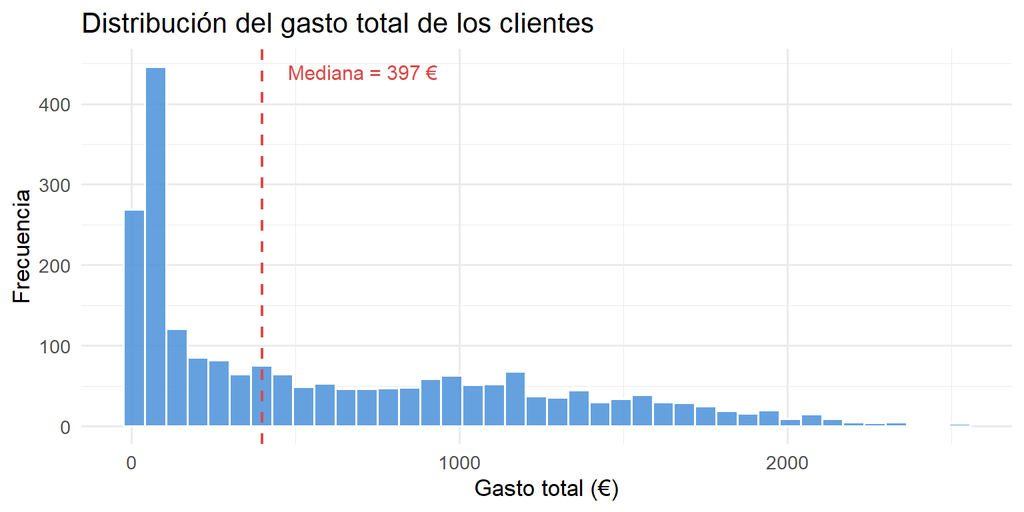

```r
ggplot(data, aes(x = Total_Spending)) +
  geom_histogram(bins = 40, fill = "#4A90D9", color = "white", alpha = 0.85) +
  geom_vline(aes(xintercept = median(Total_Spending)),
    color = "#D94A4A", linetype = "dashed", linewidth = 0.8
  ) +
  annotate("text",
    x = median(data$Total_Spending) + 80, y = Inf,
    label = paste0("Mediana = ", round(median(data$Total_Spending), 0), " €"),
    vjust = 2, hjust = 0, color = "#D94A4A", size = 4
  ) +
  labs(
    title = "Distribución del gasto total de los clientes",
    x = "Gasto total (€)", y = "Frecuencia"
  ) +
  theme_minimal(base_size = 13)
```

La distribución presenta una clara **asimetría positiva** (sesgo a la derecha), lo que indica que la mayoría de los clientes gastan cantidades moderadas, mientras que un grupo reducido presenta gastos muy elevados. Este patrón es habitual en contextos de consumo y avala el uso de terciles como criterio de segmentación, ya que garantiza grupos de tamaño similar y robustez frente a valores extremos.

*Nota metodológica: se opta por terciles para conseguir tamaños muestrales equilibrados que maximicen la potencia de los tests estadísticos y del modelado posterior. En un contexto de producción, una segmentación basada en el principio de Pareto (p. ej. el top 10-20 % de clientes) podría resultar más realista desde la perspectiva de negocio, aunque implicaría trabajar con grupos muy desbalanceados.*

### 3.2. Creación de segmentos

Dividimos la variable `Total_Spending` en tres segmentos utilizando terciles, de modo que cada grupo contenga aproximadamente un tercio de los clientes:

- **Bajo**: clientes en el tercio inferior de gasto.
- **Medio**: clientes en el tercio intermedio.
- **Alto**: clientes en el tercio superior de gasto.

```r
cortes <- quantile(data$Total_Spending, probs = c(0, 1 / 3, 2 / 3, 1))
cat("Puntos de corte (terciles):", cortes, "\n")
```

```
## Puntos de corte (terciles): 8 116.6667 835 2525
```

```r
data <- data %>%
  mutate(
    Segmento_Gasto = cut(
      Total_Spending,
      breaks = cortes,
      include.lowest = TRUE,
      labels = c("Bajo", "Medio", "Alto")
    )
  )

data %>% count(Segmento_Gasto)
```

```
## # A tibble: 3 × 2
##   Segmento_Gasto     n
##   <fct>          <int>
## 1 Bajo             734
## 2 Medio            735
## 3 Alto             733
```

## 4. Análisis descriptivo comparativo

### 4.1. Variables numéricas por segmento

Comparamos las medias y medianas de las principales variables numéricas entre los tres segmentos. El uso conjunto de ambas medidas permite detectar la influencia de valores extremos.

```r
vars_numericas <- c(
  "Age", "Income", "Children_Home",
  "Total_Purchases", "NumWebPurchases", "NumCatalogPurchases",
  "NumStorePurchases", "NumDealsPurchases", "Deals_Ratio",
  "NumWebVisitsMonth", "Recency", "Tenure_Days",
  "Total_Campaigns_Accepted"
)

# Tamaño de cada segmento (ya mostrado en la sección anterior)

resumen_segmentos <- data %>%
  group_by(Segmento_Gasto) %>%
  summarise(
    across(
      all_of(vars_numericas),
      list(
        Media = ~ round(mean(.x, na.rm = TRUE), 2),
        Mediana = ~ round(median(.x, na.rm = TRUE), 2)
      ),
      .names = "{.col}__{.fn}"
    ),
    .groups = "drop"
  )

# Mostramos la tabla transpuesta para mayor legibilidad
resumen_largo <- resumen_segmentos %>%
  pivot_longer(
    cols = -Segmento_Gasto,
    names_to = c("Variable", "Estadistico"),
    names_sep = "__"
  ) %>%
  pivot_wider(
    names_from = c(Segmento_Gasto, Estadistico),
    values_from = value,
    names_sep = " - "
  )

print(resumen_largo, n = Inf, width = Inf)
```

```
## # A tibble: 13 × 7
##    Variable                 `Bajo - Media` `Bajo - Mediana` `Medio - Media`
##    <chr>                             <dbl>            <dbl>           <dbl>
##  1 Age                               41.8             41              46.6
##  2 Income                         32599.           31163           51044.
##  3 Children_Home                      1.29             1               1.11
##  4 Total_Purchases                    4.75             5              13.1
##  5 NumWebPurchases                    1.6              1               5.02
##  6 NumCatalogPurchases                0.3              0               2.08
##  7 NumStorePurchases                  2.86             3               6.02
##  8 NumDealsPurchases                  1.75             1               3.19
##  9 Deals_Ratio                        0.36             0.33            0.26
## 10 NumWebVisitsMonth                  6.43             7               5.75
## 11 Recency                           48.5             49              48.5
## 12 Tenure_Days                      491.             479             550.
```

[output cut: 16 more lines]

### 4.2. Composición del gasto por categoría de producto

Para entender **en qué gastan** los clientes de cada segmento, calculamos la proporción media de gasto en cada categoría respecto al gasto total.

```r
data <- data %>%
  mutate(
    Pct_Wines = ifelse(Total_Spending > 0, MntWines / Total_Spending * 100, 0),
    Pct_Meat  = ifelse(Total_Spending > 0, MntMeatProducts / Total_Spending * 100, 0),
    Pct_Gold  = ifelse(Total_Spending > 0, MntGoldProds / Total_Spending * 100, 0),
    Pct_Fish  = ifelse(Total_Spending > 0, MntFishProducts / Total_Spending * 100, 0),
    Pct_Sweet = ifelse(Total_Spending > 0, MntSweetProducts / Total_Spending * 100, 0),
    Pct_Fruit = ifelse(Total_Spending > 0, MntFruits / Total_Spending * 100, 0)
  )

composicion <- data %>%
  group_by(Segmento_Gasto) %>%
  summarise(
    Vinos = round(mean(Pct_Wines), 1),
    Carne = round(mean(Pct_Meat), 1),
    Oro = round(mean(Pct_Gold), 1),
    Pescado = round(mean(Pct_Fish), 1),
    Dulces = round(mean(Pct_Sweet), 1),
    Fruta = round(mean(Pct_Fruit), 1),
    .groups = "drop"
  )

composicion
```

```
## # A tibble: 3 × 7
##   Segmento_Gasto Vinos Carne   Oro Pescado Dulces Fruta
##   <fct>          <dbl> <dbl> <dbl>   <dbl>  <dbl> <dbl>
## 1 Bajo            35.6  24.3  18.4     9.3    6.3   6.1
## 2 Medio           52.2  21.8  11.5     5.9    4.3   4.2
## 3 Alto            50    28.7   6       6.3    4.6   4.4
```

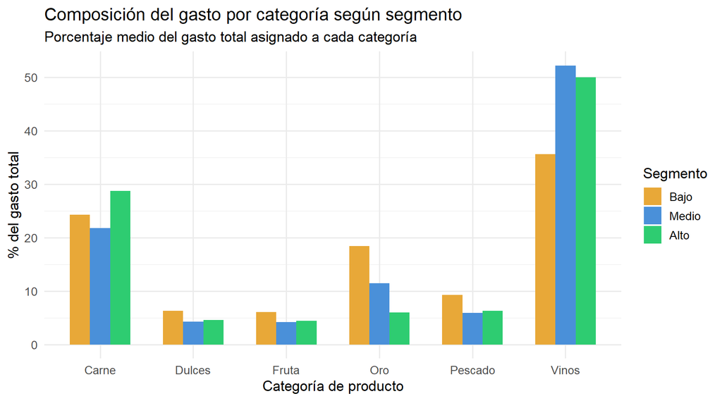

```r
composicion_long <- composicion %>%
  pivot_longer(-Segmento_Gasto, names_to = "Categoria", values_to = "Porcentaje")

ggplot(composicion_long, aes(x = Categoria, y = Porcentaje, fill = Segmento_Gasto)) +
  geom_col(position = "dodge", width = 0.65) +
  scale_fill_manual(values = c("Bajo" = "#E8A838", "Medio" = "#4A90D9", "Alto" = "#2ECC71")) +
  labs(
    title = "Composición del gasto por categoría según segmento",
    subtitle = "Porcentaje medio del gasto total asignado a cada categoría",
    x = "Categoría de producto", y = "% del gasto total", fill = "Segmento"
  ) +
  theme_minimal(base_size = 13)
```

### 4.3. Variables categóricas por segmento

#### 4.3.1. Nivel educativo

```r
tabla_edu <- data %>%
  count(Segmento_Gasto, Education) %>%
  group_by(Segmento_Gasto) %>%
  mutate(Porcentaje = round(n / sum(n) * 100, 2)) %>%
  ungroup()

tabla_edu
```

```
## # A tibble: 15 × 4
##    Segmento_Gasto Education      n Porcentaje
##    <fct>          <ord>      <int>      <dbl>
##  1 Bajo           Basic         50       6.81
##  2 Bajo           2n Cycle      86      11.7
##  3 Bajo           Graduation   356      48.5
##  4 Bajo           Master       108      14.7
##  5 Bajo           PhD          134      18.3
##  6 Medio          Basic          3       0.41
##  7 Medio          2n Cycle      60       8.16
##  8 Medio          Graduation   368      50.1
##  9 Medio          Master       142      19.3
## 10 Medio          PhD          162      22.0
## 11 Alto           Basic          1       0.14
## 12 Alto           2n Cycle      52       7.09
## 13 Alto           Graduation   386      52.7
## 14 Alto           Master       114      15.6
## 15 Alto           PhD          180      24.6
```

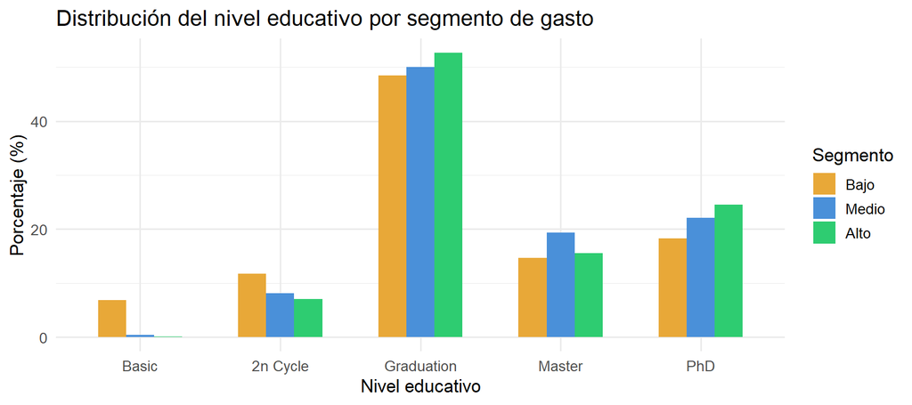

```r
ggplot(tabla_edu, aes(x = Education, y = Porcentaje, fill = Segmento_Gasto)) +
  geom_col(position = "dodge", width = 0.6) +
  scale_fill_manual(values = c("Bajo" = "#E8A838", "Medio" = "#4A90D9", "Alto" = "#2ECC71")) +
  labs(
    title = "Distribución del nivel educativo por segmento de gasto",
    x = "Nivel educativo", y = "Porcentaje (%)", fill = "Segmento"
  ) +
  theme_minimal(base_size = 13)
```

#### 4.3.2. Estado civil

```r
tabla_ms <- data %>%
  count(Segmento_Gasto, Marital_Status) %>%
  group_by(Segmento_Gasto) %>%
  mutate(Porcentaje = round(n / sum(n) * 100, 2)) %>%
  ungroup()

tabla_ms
```

```
## # A tibble: 15 × 4
##    Segmento_Gasto Marital_Status     n Porcentaje
##    <fct>          <fct>          <int>      <dbl>
##  1 Bajo           Single           163      22.2
##  2 Bajo           Together         193      26.3
##  3 Bajo           Married          288      39.2
##  4 Bajo           Divorced          75      10.2
##  5 Bajo           Widow             15       2.04
##  6 Medio          Single           156      21.2
##  7 Medio          Together         193      26.3
##  8 Medio          Married          287      39.0
##  9 Medio          Divorced          71       9.66
## 10 Medio          Widow             28       3.81
## 11 Alto           Single           152      20.7
## 12 Alto           Together         186      25.4
## 13 Alto           Married          280      38.2
## 14 Alto           Divorced          82      11.2
## 15 Alto           Widow             33       4.5
```

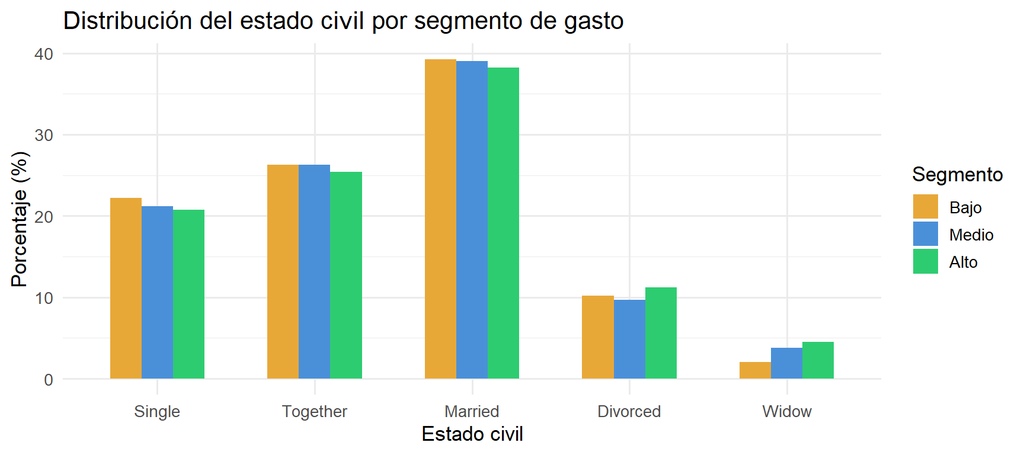

```r
ggplot(tabla_ms, aes(x = Marital_Status, y = Porcentaje, fill = Segmento_Gasto)) +
  geom_col(position = "dodge", width = 0.6) +
  scale_fill_manual(values = c("Bajo" = "#E8A838", "Medio" = "#4A90D9", "Alto" = "#2ECC71")) +
  labs(
    title = "Distribución del estado civil por segmento de gasto",
    x = "Estado civil", y = "Porcentaje (%)", fill = "Segmento"
  ) +
  theme_minimal(base_size = 13)
```

El estado civil tampoco muestra un patrón claro de diferenciación: las proporciones de solteros, casados y en pareja son similares en los tres segmentos. Esto indica que la situación sentimental no está fuertemente asociada al nivel de gasto.

#### 4.3.3. Presencia de hijos en el hogar

```r
tabla_hijos <- data %>%
  mutate(Has_Children_Label = ifelse(Has_Children == 1, "Con hijos", "Sin hijos")) %>%
  count(Segmento_Gasto, Has_Children_Label) %>%
  group_by(Segmento_Gasto) %>%
  mutate(Porcentaje = round(n / sum(n) * 100, 2)) %>%
  ungroup()

tabla_hijos
```

```
## # A tibble: 6 × 4
##   Segmento_Gasto Has_Children_Label     n Porcentaje
##   <fct>          <chr>              <int>      <dbl>
## 1 Bajo           Con hijos            660       89.9
## 2 Bajo           Sin hijos             74       10.1
## 3 Medio          Con hijos            619       84.2
## 4 Medio          Sin hijos            116       15.8
## 5 Alto           Con hijos            298       40.6
## 6 Alto           Sin hijos            435       59.4
```

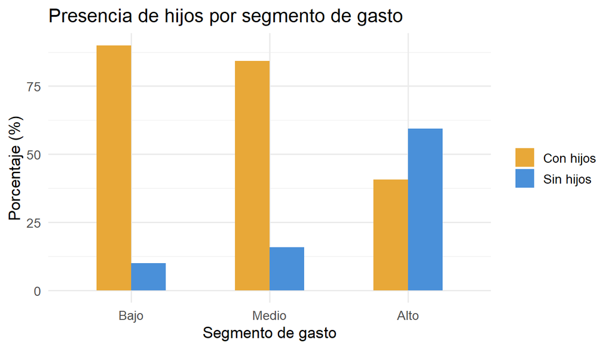

```r
ggplot(tabla_hijos, aes(x = Segmento_Gasto, y = Porcentaje, fill = Has_Children_Label)) +
  geom_col(position = "dodge", width = 0.5) +
  scale_fill_manual(values = c("Con hijos" = "#E8A838", "Sin hijos" = "#4A90D9")) +
  labs(
    title = "Presencia de hijos por segmento de gasto",
    x = "Segmento de gasto", y = "Porcentaje (%)", fill = NULL
  ) +
  theme_minimal(base_size = 13)
```

Aquí sí se aprecia una diferencia más notable: en el segmento de gasto **alto**, la proporción de clientes **sin hijos** es mayor que en los segmentos medio y bajo. Esto apunta a que la ausencia de cargas familiares podría liberar renta disponible para consumo personal.

El análisis descriptivo revela diferencias claras entre los tres segmentos en la mayoría de variables. A continuación, profundizamos con visualizaciones que permiten apreciar la magnitud y distribución de estas diferencias.

## 5. Visualización de variables clave

### 5.1. Ingresos por segmento

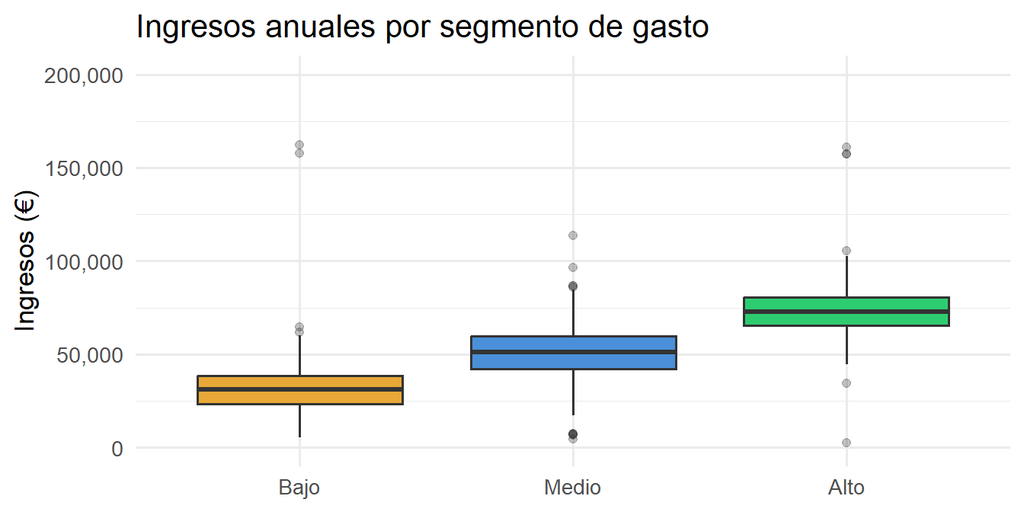

```r
ggplot(data, aes(x = Segmento_Gasto, y = Income, fill = Segmento_Gasto)) +
  geom_boxplot(outlier.alpha = 0.3) +
  scale_fill_manual(values = c("Bajo" = "#E8A838", "Medio" = "#4A90D9", "Alto" = "#2ECC71")) +
  scale_y_continuous(labels = scales::comma) +
  coord_cartesian(ylim = c(0, 200000)) +
  labs(title = "Ingresos anuales por segmento de gasto", x = NULL, y = "Ingresos (€)") +
  theme_minimal(base_size = 13) +
  theme(legend.position = "none")
```

Se observa una separación nítida entre segmentos: la mediana de ingresos del segmento Alto es notablemente superior a la del Bajo, con escaso solapamiento entre las cajas. Esto confirma que la **capacidad económica** es uno de los factores que más diferencia a los clientes de alto valor, aunque no es el único (como veremos en el análisis de importancia de la sección 9).

### 5.2. Edad por segmento

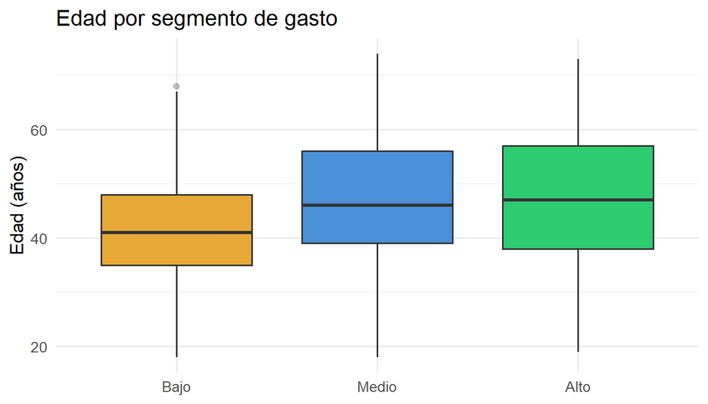

```r
ggplot(data, aes(x = Segmento_Gasto, y = Age, fill = Segmento_Gasto)) +
  geom_boxplot(outlier.alpha = 0.3) +
  scale_fill_manual(values = c("Bajo" = "#E8A838", "Medio" = "#4A90D9", "Alto" = "#2ECC71")) +
  labs(title = "Edad por segmento de gasto", x = NULL, y = "Edad (años)") +
  theme_minimal(base_size = 13) +
  theme(legend.position = "none")
```

La edad no presenta diferencias tan marcadas entre segmentos como los ingresos. Las cajas están muy solapadas, lo que indica que **la edad no es un factor determinante** para diferenciar clientes de alto y bajo valor. Todas las franjas de edad pueden presentar niveles de gasto variados.

### 5.3. Compras por canal

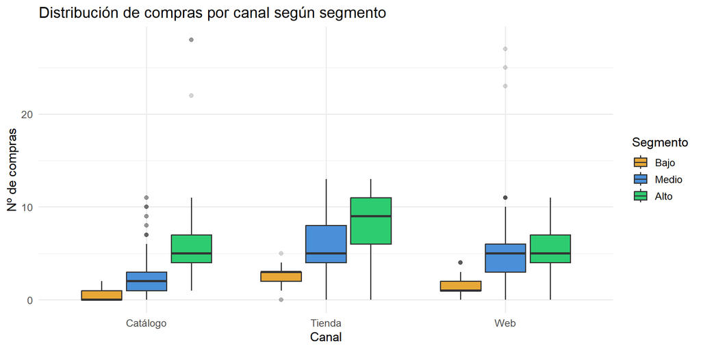

```r
vars_canal <- c("NumWebPurchases", "NumCatalogPurchases", "NumStorePurchases")

data_canal <- data %>%
  select(Segmento_Gasto, all_of(vars_canal)) %>%
  pivot_longer(cols = all_of(vars_canal), names_to = "Canal", values_to = "Compras") %>%
  mutate(Canal = case_when(
    Canal == "NumWebPurchases" ~ "Web",
    Canal == "NumCatalogPurchases" ~ "Catálogo",
    Canal == "NumStorePurchases" ~ "Tienda"
  ))

ggplot(data_canal, aes(x = Canal, y = Compras, fill = Segmento_Gasto)) +
  geom_boxplot(outlier.alpha = 0.2) +
  scale_fill_manual(values = c("Bajo" = "#E8A838", "Medio" = "#4A90D9", "Alto" = "#2ECC71")) +
  labs(
    title = "Distribución de compras por canal según segmento",
    x = "Canal", y = "Nº de compras", fill = "Segmento"
  ) +
  theme_minimal(base_size = 13)
```

Los tres segmentos comparten el **mismo orden de preferencia de canal**: tienda > web > catálogo. La diferencia entre segmentos no es de patrón, sino de **volumen**: los clientes de alto valor compran más en todos los canales. Sin embargo, hay un matiz relevante: en el segmento Alto, las compras por **catálogo se acercan en volumen a las de web**, mientras que en los segmentos Medio y Bajo la brecha entre ambos canales es mayor. Esto indica que los clientes de alto valor tienen una preferencia *relativa* mayor por el catálogo en comparación con los demás segmentos, aunque —como se analiza en la sección 9— parte de esta relación es mecánica: quien compra más veces, gasta más.

### 5.4. Dependencia de descuentos (Deals_Ratio)

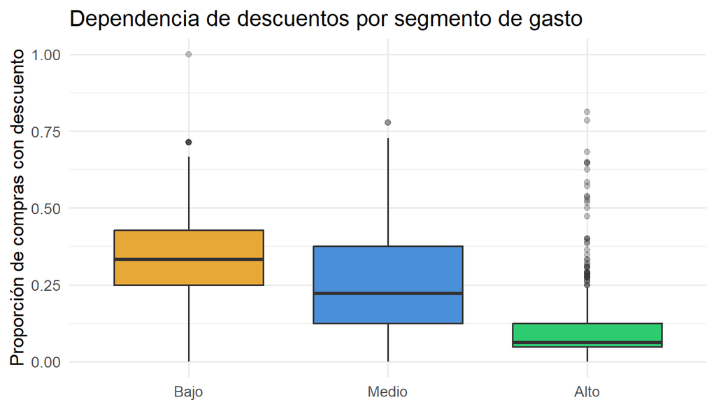

```r
ggplot(data, aes(x = Segmento_Gasto, y = Deals_Ratio, fill = Segmento_Gasto)) +
  geom_boxplot(outlier.alpha = 0.3) +
  scale_fill_manual(values = c("Bajo" = "#E8A838", "Medio" = "#4A90D9", "Alto" = "#2ECC71")) +
  labs(
    title = "Dependencia de descuentos por segmento de gasto",
    x = NULL, y = "Proporción de compras con descuento"
  ) +
  coord_cartesian(ylim = c(0, 1)) +
  theme_minimal(base_size = 13) +
  theme(legend.position = "none")
```

Se aprecia un patrón interesante: los clientes de gasto **bajo** presentan la mayor proporción de compras con descuento, mientras que los de gasto **alto** recurren menos a ofertas. Esto podría indicar que los clientes de alto valor son menos sensibles al precio o que su cesta de compra habitual (vinos, carne) se ve menos afectada por promociones.

> **Hallazgo:** El `Deals_Ratio` actúa de forma inversa al valor del cliente: a mayor gasto, menor dependencia de descuentos. Este hallazgo tiene implicaciones directas para la gestión de márgenes: las promociones captan al segmento menos valioso, mientras el segmento premium compra a precio completo de forma autónoma.

### 5.5. Visitas web mensuales

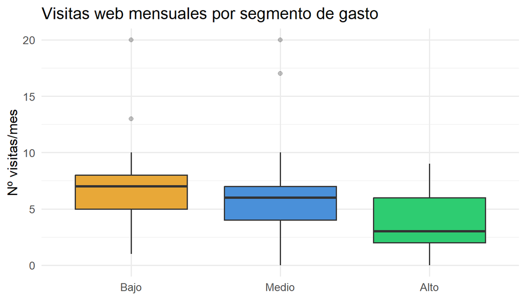

```r
ggplot(data, aes(x = Segmento_Gasto, y = NumWebVisitsMonth, fill = Segmento_Gasto)) +
  geom_boxplot(outlier.alpha = 0.3) +
  scale_fill_manual(values = c("Bajo" = "#E8A838", "Medio" = "#4A90D9", "Alto" = "#2ECC71")) +
  labs(
    title = "Visitas web mensuales por segmento de gasto",
    x = NULL, y = "Nº visitas/mes"
  ) +
  theme_minimal(base_size = 13) +
  theme(legend.position = "none")
```

Paradójicamente, los clientes de gasto **bajo** visitan **más** la web que los de gasto alto. Esto podría reflejar un comportamiento más informacional o comparativo (buscar ofertas, comparar productos) frente al comportamiento más decisivo de los clientes de alto valor, que compran directamente por catálogo o en tienda.

> **Hallazgo — Paradoja del navegante:** Los clientes que más visitan la web son precisamente los que menos gastan. La web funciona más como canal de búsqueda de ofertas que como canal de compra de alto ticket. Este resultado conecta con el concepto de “navegante vs. comprador” y anticipa la paradoja desarrollada en el segundo notebook individual.

### 5.6. Campañas aceptadas

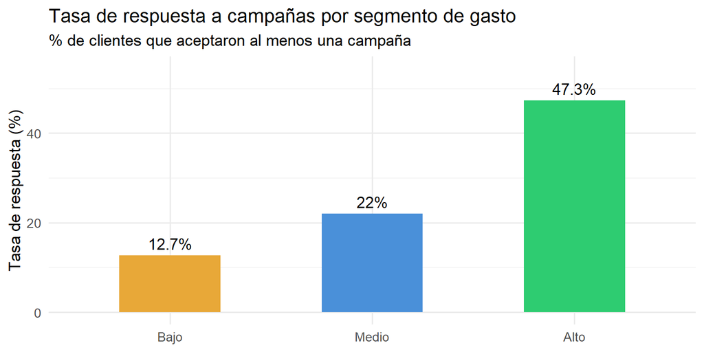

```r
tasa_campanas <- data %>%
  group_by(Segmento_Gasto) %>%
  summarise(
    Tasa_respuesta = round(mean(Responded_Any_Campaign) * 100, 1),
    Media_campannas = round(mean(Total_Campaigns_Accepted), 2),
    .groups = "drop"
  )

ggplot(tasa_campanas, aes(x = Segmento_Gasto, y = Tasa_respuesta, fill = Segmento_Gasto)) +
  geom_col(width = 0.5) +
  geom_text(aes(label = paste0(Tasa_respuesta, "%")), vjust = -0.5, size = 4.5) +
  scale_fill_manual(values = c("Bajo" = "#E8A838", "Medio" = "#4A90D9", "Alto" = "#2ECC71")) +
  labs(
    title = "Tasa de respuesta a campañas por segmento de gasto",
    subtitle = "% de clientes que aceptaron al menos una campaña",
    x = NULL, y = "Tasa de respuesta (%)"
  ) +
  theme_minimal(base_size = 13) +
  theme(legend.position = "none") +
  ylim(0, max(tasa_campanas$Tasa_respuesta) * 1.15)
```

### 5.7. Relación entre ingresos y gasto total

```
## 'y ~ x'
```

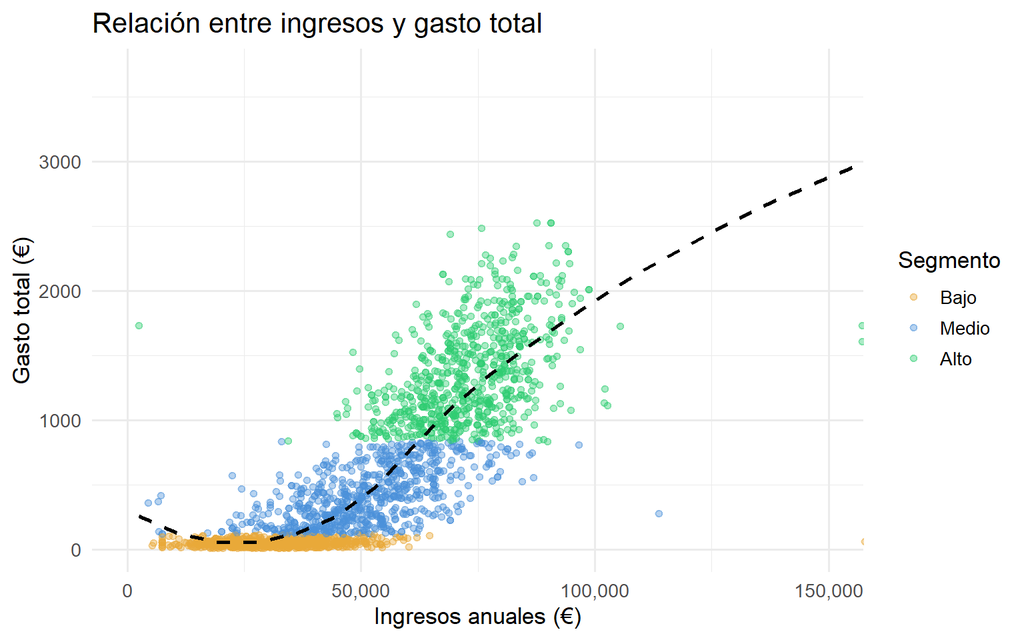

```r
ggplot(data, aes(x = Income, y = Total_Spending, color = Segmento_Gasto)) +
  geom_point(alpha = 0.4, size = 1.5) +
  geom_smooth(aes(color = NULL),
    method = "loess", se = FALSE,
    linewidth = 1, linetype = "dashed", color = "black"
  ) +
  scale_color_manual(values = c("Bajo" = "#E8A838", "Medio" = "#4A90D9", "Alto" = "#2ECC71")) +
  scale_x_continuous(labels = scales::comma) +
  coord_cartesian(xlim = c(0, 150000)) +
  labs(
    title = "Relación entre ingresos y gasto total",
    x = "Ingresos anuales (€)", y = "Gasto total (€)", color = "Segmento"
  ) +
  theme_minimal(base_size = 13)
```

El *scatter plot* muestra una relación positiva clara entre ingresos y gasto total, especialmente visible en la curva LOESS global. Sin embargo, dentro de cada segmento, la dispersión es considerable: para un mismo nivel de ingresos, los clientes pueden pertenecer a segmentos distintos. Esto refuerza la idea de que **los ingresos, por sí solos, no determinan completamente el nivel de gasto**.

## 6. Análisis inferencial

### 6.1. Planteamiento estadístico

Para determinar si las diferencias observadas entre segmentos son estadísticamente significativas, aplicamos los siguientes tests:

- **Variables numéricas**: test de **Kruskal-Wallis** (alternativa no paramétrica al ANOVA de un factor), adecuado para comparar tres o más grupos sin asumir normalidad.
- **Variables categóricas**: test **Chi-cuadrado de independencia**, que evalúa si la distribución de una variable categórica es independiente del segmento de gasto.

Se adopta un nivel de significación $\alpha = 0.05$.

### 6.2. Tests para variables numéricas (Kruskal-Wallis)

Planteamiento formal del contraste:

- **H₀**: La distribución de cada variable numérica es la misma en los tres segmentos de gasto.
- **H₁**: Al menos un segmento presenta una distribución distinta.

Se rechaza H₀ si el p-valor < α = 0.05.

```r
resultados_kw <- data.frame(
  Variable = vars_numericas,
  Estadistico = NA_real_,
  p_valor = NA_real_,
  Epsilon2 = NA_real_,
  stringsAsFactors = FALSE
)

for (i in seq_along(vars_numericas)) {
  v <- vars_numericas[i]
  test <- kruskal.test(reformulate("Segmento_Gasto", response = v), data = data)
  n <- nrow(data)
  k <- 3 # número de grupos
  H <- as.numeric(test$statistic)
  resultados_kw$Estadistico[i] <- round(H, 2)
  resultados_kw$p_valor[i] <- round(test$p.value, 6)
  resultados_kw$Epsilon2[i] <- round((H - k + 1) / (n - k), 4)
}

resultados_kw$Significativa <- ifelse(resultados_kw$p_valor < 0.05, "Sí", "No")

knitr::kable(resultados_kw,
  digits = 4,
  caption = "Kruskal-Wallis y tamaño del efecto (ε²) por variable"
)
```

Kruskal-Wallis y tamaño del efecto (ε²) por variable

| Variable | Estadistico | p_valor | Epsilon2 | Significativa |
| --- | --- | --- | --- | --- |
| Age | 90.62 | 0.0000 | 0.0403 | Sí |
| Income | 1504.22 | 0.0000 | 0.6831 | Sí |
| Children_Home | 539.11 | 0.0000 | 0.2443 | Sí |
| Total_Purchases | 1700.78 | 0.0000 | 0.7725 | Sí |
| NumWebPurchases | 1244.08 | 0.0000 | 0.5648 | Sí |
| NumCatalogPurchases | 1652.97 | 0.0000 | 0.7508 | Sí |
| NumStorePurchases | 1397.93 | 0.0000 | 0.6348 | Sí |
| NumDealsPurchases | 305.57 | 0.0000 | 0.1380 | Sí |
| Deals_Ratio | 1014.43 | 0.0000 | 0.4604 | Sí |
| NumWebVisitsMonth | 503.14 | 0.0000 | 0.2279 | Sí |
| Recency | 1.48 | 0.4777 | -0.0002 | No |
| Tenure_Days | 68.36 | 0.0000 | 0.0302 | Sí |
| Total_Campaigns_Accepted | 276.09 | 0.0000 | 0.1246 | Sí |

> Los valores de ε² > 0.14 se interpretan como efecto grande. Un ε² cercano a 0 indica que el segmento explica poca variabilidad de esa variable, aunque el p-valor sea significativo por el tamaño muestral.

```r
vars_significativas <- resultados_kw$Variable[resultados_kw$Significativa == "Sí"]
```

### 6.3. Tests para variables categóricas (Chi-cuadrado)

Planteamiento formal:

- **H₀**: La variable categórica y el segmento de gasto son independientes.
- **H₁**: Existe asociación estadísticamente significativa entre ambas variables.

```r
cat("=== Education vs Segmento_Gasto ===\n")
```

```
## === Education vs Segmento_Gasto ===
```

```r
tabla_edu_test <- table(data$Education, data$Segmento_Gasto)
test_edu <- chisq.test(tabla_edu_test)
print(test_edu)
```

```
##
##  Pearson's Chi-squared test
##
## data:  tabla_edu_test
## X-squared = 108.46, df = 8, p-value < 2.2e-16
```

```r
cat("\n=== Marital_Status vs Segmento_Gasto ===\n")
```

```
##
## === Marital_Status vs Segmento_Gasto ===
```

```r
tabla_ms_test <- table(data$Marital_Status, data$Segmento_Gasto)
test_ms <- chisq.test(tabla_ms_test)
print(test_ms)
```

```
##
##  Pearson's Chi-squared test
##
## data:  tabla_ms_test
## X-squared = 8.3318, df = 8, p-value = 0.4017
```

```r
cat("\n=== Has_Children vs Segmento_Gasto ===\n")
```

```
##
## === Has_Children vs Segmento_Gasto ===
```

```r
tabla_hijos_test <- table(data$Has_Children, data$Segmento_Gasto)
test_hijos <- chisq.test(tabla_hijos_test)
print(test_hijos)
```

```
##
##  Pearson's Chi-squared test
##
## data:  tabla_hijos_test
## X-squared = 524.05, df = 2, p-value < 2.2e-16
```

### 6.4. Resumen de significación estadística

```r
cat("========================================\n")
cat("RESUMEN DE SIGNIFICACIÓN ESTADÍSTICA\n")
```

```
## RESUMEN DE SIGNIFICACIÓN ESTADÍSTICA
```

```r
cat("========================================\n\n")
cat("--- Variables numéricas (Kruskal-Wallis) ---\n")
```

```
## --- Variables numéricas (Kruskal-Wallis) ---
```

```r
cat("Significativas:\n")
```

```
## Significativas:
```

```r
for (v in vars_significativas) {
  p <- resultados_kw$p_valor[resultados_kw$Variable == v]
  cat(paste0("  ✓ ", v, " (p = ", p, ")\n"))
}
```

```
##   ✓ Age (p = 0)
##   ✓ Income (p = 0)
##   ✓ Children_Home (p = 0)
##   ✓ Total_Purchases (p = 0)
##   ✓ NumWebPurchases (p = 0)
##   ✓ NumCatalogPurchases (p = 0)
##   ✓ NumStorePurchases (p = 0)
##   ✓ NumDealsPurchases (p = 0)
##   ✓ Deals_Ratio (p = 0)
##   ✓ NumWebVisitsMonth (p = 0)
##   ✓ Tenure_Days (p = 0)
##   ✓ Total_Campaigns_Accepted (p = 0)
```

```r
vars_no_sig <- resultados_kw$Variable[resultados_kw$Significativa == "No"]
if (length(vars_no_sig) > 0) {
  cat("No significativas:\n")
  for (v in vars_no_sig) {
    p <- resultados_kw$p_valor[resultados_kw$Variable == v]
    cat(paste0("  ✗ ", v, " (p = ", p, ")\n"))
  }
}
```

```
## No significativas:
##   ✗ Recency (p = 0.477661)
```

```r
cat("\n--- Variables categóricas (Chi-cuadrado) ---\n")
```

```
##
## --- Variables categóricas (Chi-cuadrado) ---
```

```r
cat(paste0(
  "  Education:      p = ", format.pval(test_edu$p.value, digits = 4),
  " → ", ifelse(test_edu$p.value < 0.05, "Significativa ✓", "No significativa ✗"), "\n"
))
```

```
##   Education:      p = < 2.2e-16 → Significativa ✓
```

```r
cat(paste0(
  "  Marital_Status: p = ", format.pval(test_ms$p.value, digits = 4),
  " → ", ifelse(test_ms$p.value < 0.05, "Significativa ✓", "No significativa ✗"), "\n"
))
```

```
##   Marital_Status: p = 0.4017 → No significativa ✗
```

```r
cat(paste0(
  "  Has_Children:   p = ", format.pval(test_hijos$p.value, digits = 4),
  " → ", ifelse(test_hijos$p.value < 0.05, "Significativa ✓", "No significativa ✗"), "\n"
))
```

```
##   Has_Children:   p = < 2.2e-16 → Significativa ✓
```

## 7. Perfil tipo del cliente de alto valor

A partir de los resultados descriptivos e inferenciales, sintetizamos las características que definen al cliente de alto valor (segmento **Alto**), contrastándolas con el segmento **Bajo**.

```r
perfil_comparativo <- data %>%
  filter(Segmento_Gasto %in% c("Bajo", "Alto")) %>%
  group_by(Segmento_Gasto) %>%
  summarise(
    n = as.character(n()),
    Gasto_total_medio = as.character(round(mean(Total_Spending), 0)),
    Ingreso_medio = as.character(round(mean(Income, na.rm = TRUE), 0)),
    Edad_media = as.character(round(mean(Age), 1)),
    Hijos_media = as.character(round(mean(Children_Home), 2)),
    Pct_sin_hijos = as.character(round(mean(Has_Children == 0) * 100, 1)),
    Compras_totales = as.character(round(mean(Total_Purchases), 1)),
    Compras_catalogo = as.character(round(mean(NumCatalogPurchases), 1)),
    Compras_tienda = as.character(round(mean(NumStorePurchases), 1)),
    Compras_web = as.character(round(mean(NumWebPurchases), 1)),
    Deals_Ratio = as.character(round(mean(Deals_Ratio), 3)),
    Visitas_web_mes = as.character(round(mean(NumWebVisitsMonth), 1)),
    Tasa_campanna = as.character(round(mean(Responded_Any_Campaign) * 100, 1)),
    Recencia_media = as.character(round(mean(Recency), 1)),
    Educacion_moda = names(sort(table(Education), decreasing = TRUE))[1],
    Estado_civil_moda = names(sort(table(Marital_Status), decreasing = TRUE))[1],
    .groups = "drop"
  )

perfil_largo <- perfil_comparativo %>%
  pivot_longer(-Segmento_Gasto, names_to = "Caracteristica", values_to = "Valor") %>%
  pivot_wider(names_from = Segmento_Gasto, values_from = Valor)

perfil_largo
```

```
## # A tibble: 16 × 3
##    Caracteristica    Bajo       Alto
##    <chr>             <chr>      <chr>
##  1 n                 734        733
##  2 Gasto_total_medio 52         1357
##  3 Ingreso_medio     32599      73097
##  4 Edad_media        41.8       46.9
##  5 Hijos_media       1.29       0.46
##  6 Pct_sin_hijos     10.1       59.3
##  7 Compras_totales   4.8        19.9
##  8 Compras_catalogo  0.3        5.7
##  9 Compras_tienda    2.9        8.6
## 10 Compras_web       1.6        5.7
## 11 Deals_Ratio       0.357      0.103
## 12 Visitas_web_mes   6.4        3.7
## 13 Tasa_campanna     12.7       47.3
## 14 Recencia_media    48.5       50.1
## 15 Educacion_moda    Graduation Graduation
## 16 Estado_civil_moda Married    Married
```

## 8. Árbol de decisión (CART)

### 8.1. Justificación metodológica

El análisis descriptivo e inferencial evalúa cada variable **por separado**. Para capturar **interacciones** entre variables y obtener reglas de clasificación interpretables, entrenamos un **árbol de decisión CART** (*Classification and Regression Tree*). Este enfoque presenta ventajas frente a otras alternativas:

- No requiere discretizar variables continuas, por lo que no se pierde información.
- Encuentra automáticamente los **puntos de corte óptimos** en cada variable.
- Genera un **diagrama de flujo** visual, fácilmente comunicable a *stakeholders* no técnicos.

Limitamos la profundidad del árbol a 4 niveles para mantener la interpretabilidad.

### 8.2. Entrenamiento del modelo

```r
library(rpart)
library(rpart.plot)

set.seed(42)

vars_arbol <- c(
  "Age", "Income", "Children_Home",
  "Deals_Ratio", "NumWebVisitsMonth",
  "Recency", "Tenure_Days"
)

data_tree <- data %>%
  select(Segmento_Gasto, all_of(vars_arbol)) %>%
  na.omit()

arbol <- rpart(
  Segmento_Gasto ~ .,
  data = data_tree,
  method = "class",
  control = rpart.control(maxdepth = 4, cp = 0.01)
)

arbol
```

```
## n= 2202
##
## node), split, n, loss, yval, (yprob)
##       * denotes terminal node
##
##  1) root 2202 1467 Medio (0.333333333 0.333787466 0.332879201)
##    2) Income< 52199 1123  415 Bajo (0.630454141 0.352626892 0.016918967)
##      4) Income< 39550 709  135 Bajo (0.809590973 0.187588152 0.002820874)
##        8) Deals_Ratio>=0.1547619 683  112 Bajo (0.836017570 0.161054173 0.002928258) *
##        9) Deals_Ratio< 0.1547619 26    3 Medio (0.115384615 0.884615385 0.000000000) *
##      5) Income>=39550 414  151 Medio (0.323671498 0.635265700 0.041062802)
##       10) Tenure_Days< 395.5 114   47 Bajo (0.587719298 0.412280702 0.000000000)
##         20) Deals_Ratio>=0.1909091 84   22 Bajo (0.738095238 0.261904762 0.000000000) *
##         21) Deals_Ratio< 0.1909091 30    5 Medio (0.166666667 0.833333333 0.000000000) *
##       11) Tenure_Days>=395.5 300   84 Medio (0.223333333 0.720000000 0.056666667) *
##    3) Income>=52199 1079  365 Alto (0.024096386 0.314179796 0.661723818)
##      6) Income< 66534 468  204 Medio (0.049145299 0.564102564 0.386752137)
##       12) Tenure_Days< 588.5 261   78 Medio (0.076628352 0.701149425 0.222222222) *
##       13) Tenure_Days>=588.5 207   84 Alto (0.014492754 0.391304348 0.594202899)
##         26) Children_Home>=1.5 43   11 Medio (0.069767442 0.744186047 0.186046512) *
##         27) Children_Home< 1.5 164   49 Alto (0.000000000 0.298780488 0.701219512) *
##      7) Income>=66534 611   78 Alto (0.004909984 0.122749591 0.872340426) *
```

### 8.3. Visualización del árbol

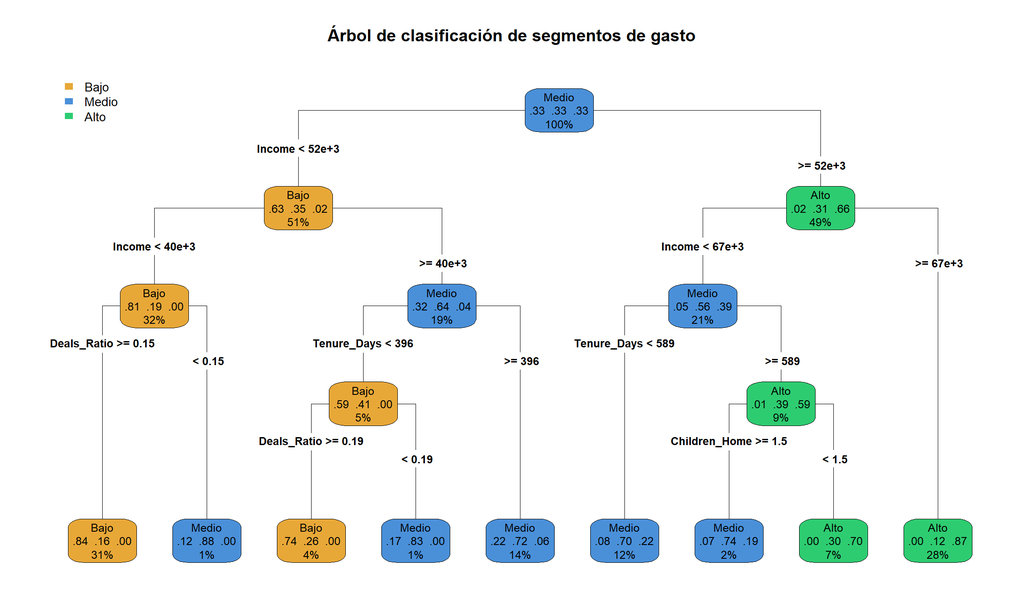

```r
rpart.plot(
  arbol,
  type = 4,
  extra = 104,
  fallen.leaves = TRUE,
  roundint = FALSE,
  main = "Árbol de clasificación de segmentos de gasto",
  box.palette = list("#E8A838", "#4A90D9", "#2ECC71")
)
```

### 8.4. Interpretación

```r
printcp(arbol)
```

```
##
## Classification tree:
## rpart(formula = Segmento_Gasto ~ ., data = data_tree, method = "class",
##     control = rpart.control(maxdepth = 4, cp = 0.01))
##
## Variables actually used in tree construction:
## [1] Children_Home Deals_Ratio   Income        Tenure_Days
##
## Root node error: 1467/2202 = 0.66621
##
## n= 2202
##
##         CP nsplit rel error  xerror     xstd
## 1 0.468303      0   1.00000 1.03817 0.014772
## 2 0.087935      1   0.53170 0.55351 0.015433
## 3 0.056578      2   0.44376 0.41990 0.014358
## 4 0.028630      3   0.38718 0.40286 0.014174
## 5 0.016360      4   0.35855 0.38037 0.013913
## 6 0.013633      5   0.34219 0.38037 0.013913
## 7 0.010000      8   0.30130 0.34901 0.013513
```

El árbol de decisión confirma que **`Income` es la variable más discriminante** desde una perspectiva de perfil, ya que es elegida como raíz del árbol. A partir del primer corte, se definen tres grandes zonas:

- **Ingresos < 39.550 €**: la gran mayoría de estos clientes pertenecen al segmento **Bajo** (81 %). Solo aquellos con un `Deals_Ratio` muy bajo (< 0.15) se desvían hacia el segmento Medio, lo que refuerza que la baja dependencia de descuentos es una señal de mayor valor incluso en rentas bajas.
- **Ingresos entre 39.550 € y 66.534 €**: esta es la **zona de transición**, donde el segmento depende de variables secundarias. Los clientes con mayor antigüedad (`Tenure_Days` > 396) tienden a ser Medio, mientras que los más recientes se clasifican como Bajo si usan mucho los descuentos. En la franja 52.000–66.500 €, los clientes con alta antigüedad y **menos de 2 hijos** alcanzan el segmento Alto (70 %), pero con 2 o más hijos se quedan en Medio.
- **Ingresos ≥ 66.534 €**: segmento **Alto** de forma casi unánime (87 %), independientemente de las demás variables.

Este análisis revela interacciones que los tests univariantes no pueden capturar: por ejemplo, la combinación *Income + Tenure_Days + Children_Home* define perfiles de forma mucho más precisa que cualquiera de estas variables por separado. Las reglas del árbol son directamente traducibles a criterios de segmentación comercial.

## 9. Importancia de variables (Random Forest)

### 9.1. Motivación

Los tests de Kruskal-Wallis y Chi-cuadrado realizados en la sección 6 permiten determinar **si** una variable difiere significativamente entre segmentos, pero no cuantifican **cuánto** contribuye cada una a la diferenciación. Para resolver esta cuestión, entrenamos un modelo de **Random Forest** con la variable objetivo `Segmento_Gasto` y extraemos la importancia de cada variable predictora mediante el índice **Mean Decrease Gini**, que mide cuánto contribuye cada variable a la pureza de los nodos de los árboles de decisión.

Este enfoque es especialmente adecuado porque:

- No requiere supuestos de distribución.
- Captura relaciones no lineales e interacciones entre variables.
- Proporciona un ranking cuantitativo e interpretable de las variables más discriminantes.

### 9.2. Entrenamiento del modelo

```r
library(randomForest)

set.seed(42)

vars_modelo <- c(
  "Age", "Income", "Children_Home",
  "NumWebPurchases", "NumCatalogPurchases", "NumStorePurchases",
  "NumDealsPurchases", "Deals_Ratio", "NumWebVisitsMonth",
  "Recency", "Tenure_Days", "Total_Campaigns_Accepted",
  "Responded_Any_Campaign"
)

data_rf <- data %>%
  select(Segmento_Gasto, all_of(vars_modelo)) %>%
  na.omit()

rf_model <- randomForest(
  Segmento_Gasto ~ .,
  data = data_rf,
  ntree = 500,
  importance = TRUE
)

rf_model
```

```
##
## Call:
##  randomForest(formula = Segmento_Gasto ~ ., data = data_rf, ntree = 500,      importance = TRUE)
##                Type of random forest: classification
##                      Number of trees: 500
## No. of variables tried at each split: 3
##
##         OOB estimate of  error rate: 6.68%
## Confusion matrix:
##       Bajo Medio Alto class.error
## Bajo   720    14    0  0.01907357
## Medio   26   640   69  0.12925170
## Alto     1    37  695  0.05184175
```

*NOTA: No se incluyen las variables de gasto por categoría (`MntWines`, `MntMeatProducts`, etc.) ni `Total_Purchases`, ya que son componentes directos de `Total_Spending`. Sí se mantienen las variables de canal de compra (`NumCatalogPurchases`, etc.) para cuantificar su importancia relativa, aunque — como se discute en la sección 9.5 — estas actúan parcialmente como proxy del gasto y se entrena un segundo modelo sin ellas para obtener una perspectiva puramente demográfica.*

### 9.3. Ranking de importancia

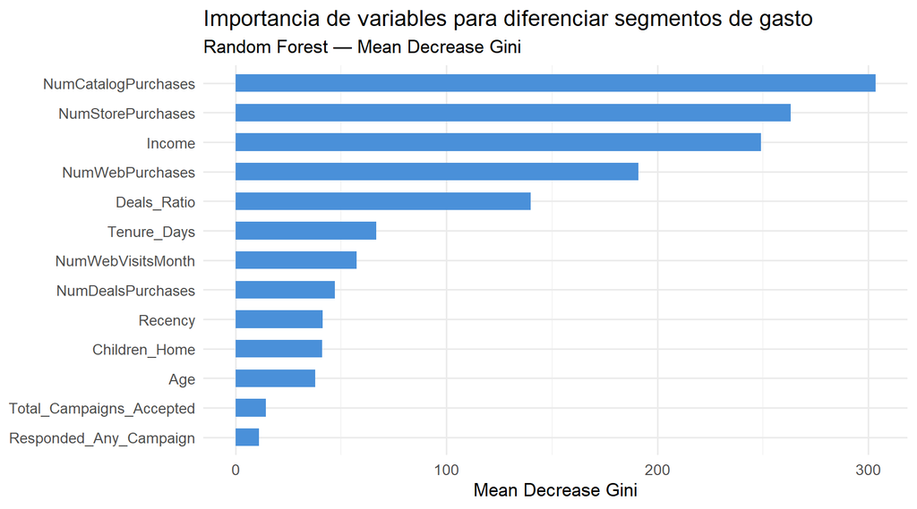

```r
importancia <- importance(rf_model, type = 2)
df_imp <- data.frame(
  Variable = rownames(importancia),
  MeanDecreaseGini = importancia[, 1]
)
df_imp <- df_imp %>% arrange(desc(MeanDecreaseGini))

ggplot(df_imp, aes(x = reorder(Variable, MeanDecreaseGini), y = MeanDecreaseGini)) +
  geom_col(fill = "#4A90D9", width = 0.6) +
  coord_flip() +
  labs(
    title = "Importancia de variables para diferenciar segmentos de gasto",
    subtitle = "Random Forest — Mean Decrease Gini",
    x = NULL, y = "Mean Decrease Gini"
  ) +
  theme_minimal(base_size = 13)
```

### 9.4. Interpretación

```r
df_imp
```

```
##                                          Variable MeanDecreaseGini
## NumCatalogPurchases           NumCatalogPurchases        303.47635
## NumStorePurchases               NumStorePurchases        263.18794
## Income                                     Income        249.16345
## NumWebPurchases                   NumWebPurchases        190.97454
## Deals_Ratio                           Deals_Ratio        139.93478
## Tenure_Days                           Tenure_Days         66.85488
## NumWebVisitsMonth               NumWebVisitsMonth         57.35282
## NumDealsPurchases               NumDealsPurchases         47.14043
## Recency                                   Recency         41.27568
## Children_Home                       Children_Home         41.11760
## Age                                           Age         37.92043
## Total_Campaigns_Accepted Total_Campaigns_Accepted         14.38916
## Responded_Any_Campaign     Responded_Any_Campaign         11.07769
```

El ranking de importancia permite identificar cuáles son las variables con mayor poder discriminante entre los tres segmentos de gasto. Las variables con mayor *Mean Decrease Gini* son aquellas que, al ser utilizadas para dividir los nodos del árbol, producen los grupos más homogéneos en términos de segmento de gasto.

Un resultado que merece discusión es que las variables de **canal de compra** (`NumCatalogPurchases`, `NumStorePurchases`, `NumWebPurchases`) se sitúan por encima de `Income` en el ranking. Esto se explica por varias razones:

- **El Mean Decrease Gini mide poder de separación, no correlación**. Las compras por catálogo y en tienda tienen una relación más directa y mecánica con el gasto total: quien compra más veces tiende a gastar más. Son casi un *proxy* del propio gasto, lo cual les otorga un poder de separación muy elevado entre los tres segmentos.
- **Los ingresos son condición necesaria pero no suficiente**. Tener ingresos altos no implica gastar mucho: existen clientes con alta capacidad económica que presentan niveles de gasto moderados. En cambio, un cliente con muchas compras por catálogo tiene una probabilidad muy alta de pertenecer al segmento de gasto alto. Por eso el modelo encuentra que las compras por canal separan los grupos de forma más *limpia* que los ingresos.
- **Income sigue siendo la 3ª variable más importante**, lo cual confirma su relevancia como factor determinante, aunque no sea el más discriminante en un contexto multivariante.

Este resultado complementa los tests inferenciales de la sección 6: mientras que los tests confirman si una variable es *estadísticamente significativa*, el Random Forest cuantifica su **relevancia relativa** en un contexto multivariante donde todas las variables compiten simultáneamente por explicar las diferencias entre segmentos.

### 9.5. Modelo alternativo: solo variables de perfil

El primer modelo incluye variables de canal de compra (`NumCatalogPurchases`, `NumStorePurchases`, `NumWebPurchases`) que son parcialmente un *proxy* del propio gasto total (quien compra más veces, gasta más). Esto explica su posición dominante y el bajo error OOB. Para aislar el poder predictivo de las **variables puramente demográficas y de perfil**, entrenamos un segundo modelo excluyendo los canales de compra y variables derivadas de ellos.

```r
set.seed(42)

vars_perfil <- c(
  "Age", "Income", "Children_Home",
  "Deals_Ratio", "NumWebVisitsMonth",
  "Recency", "Tenure_Days"
)

data_rf2 <- data %>%
  select(Segmento_Gasto, all_of(vars_perfil)) %>%
  na.omit()

rf_perfil <- randomForest(
  Segmento_Gasto ~ .,
  data = data_rf2,
  ntree = 500,
  importance = TRUE
)

rf_perfil
```

```
##
## Call:
##  randomForest(formula = Segmento_Gasto ~ ., data = data_rf2, ntree = 500,      importance = TRUE)
##                Type of random forest: classification
##                      Number of trees: 500
## No. of variables tried at each split: 2
##
##         OOB estimate of  error rate: 15.35%
## Confusion matrix:
##       Bajo Medio Alto class.error
## Bajo   658    74    2   0.1035422
## Medio   93   552   90   0.2489796
## Alto     2    77  654   0.1077763
```

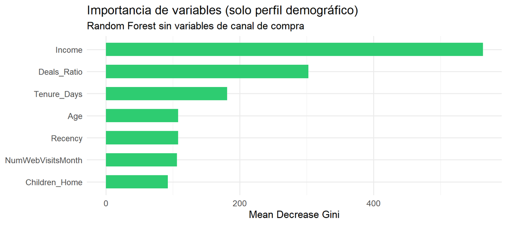

```r
imp2 <- importance(rf_perfil, type = 2)
df_imp2 <- data.frame(
  Variable = rownames(imp2),
  MeanDecreaseGini = imp2[, 1]
) %>% arrange(desc(MeanDecreaseGini))

ggplot(df_imp2, aes(x = reorder(Variable, MeanDecreaseGini), y = MeanDecreaseGini)) +
  geom_col(fill = "#2ECC71", width = 0.6) +
  coord_flip() +
  labs(
    title = "Importancia de variables (solo perfil demográfico)",
    subtitle = "Random Forest sin variables de canal de compra",
    x = NULL, y = "Mean Decrease Gini"
  ) +
  theme_minimal(base_size = 13)
```

## 10. Implicaciones de negocio

Los hallazgos de este estudio pueden traducirse en acciones comerciales concretas:

1. **Optimización de la estrategia web**: los clientes de gasto bajo visitan más la web (6-7 visitas/mes) pero compran menos, mientras que los de alto valor la visitan menos (~4) y compran por catálogo/tienda. Esto sugiere que la web actual atrae a *cazadores de ofertas* pero no convierte a clientes Premium. Se recomienda revisar la UX/UI de la tienda online para destacar productos de alto valor (vinos, carne Premium) y crear una experiencia de compra diferenciada.
2. **Política de descuentos segmentada**: los clientes de alto valor presentan un `Deals_Ratio` significativamente más bajo. Aplicar descuentos genéricos a este segmento supone una **pérdida de margen innecesaria**, ya que comprarían igualmente. Se recomienda excluir al segmento alto de las promociones masivas y sustituirlas por acciones de valor añadido (envío gratuito, acceso anticipado, catálogos exclusivos).
3. **Potenciación del canal catálogo**: el catálogo es el canal más asociado al cliente de alto valor. Invertir en catálogos físicos personalizados y en experiencias en tienda (*tastings*, eventos VIP) podría reforzar la retención de este segmento.
4. **Captación dirigida**: las reglas del árbol de decisión (sección 8) proporcionan perfiles concretos para campañas de captación. Los clientes con ingresos altos, sin hijos y baja dependencia de descuentos son los candidatos más probables a convertirse en clientes de alto valor.

## 11. Conclusiones

A lo largo de este análisis hemos abordado la pregunta: *¿Qué factores demográficos y de comportamiento caracterizan a los clientes de alto valor frente a los de bajo valor?*

En conjunto, este estudio proporciona un marco analítico multidimensional —descriptivo, inferencial y predictivo— para que la empresa pueda identificar, retener y potenciar a sus clientes más valiosos, diseñando estrategias diferenciadas según el perfil de valor.

## Referencias

Gupta, S., Hanssens, D., Hardie, B., Kahn, W., Kumar, V., Lin, N., Ravishanker, N., & Sriram, S. (2006). Modeling customer lifetime value. *Journal of Service Research*, 9(2), 139–155. https://doi.org/10.1177/1094670506293810

Kumar, V., & Reinartz, W. (2016). Creating enduring customer value. *Journal of Marketing*, 80(6), 36–68. https://doi.org/10.1509/jm.15.0414

R for Data Science. “Data Transformation: dplyr and data manipulation”. Recuperado de: https://r4ds.hadley.nz/data-transform

UC Business Analytics. “Regression Trees and Recursive Partitioning in R”. Recuperado de: https://uc-r.github.io/regression_trees